# Logit Model

Armando Rangel Galán

2024-04-30

# Expresiones básicas

Tenemos que el modelo logit es
$$\begin{eqnarray}\tag{1}\label{1}
logit(\pi_i)=\ln\left(\frac{\pi_i}{1-\pi_i}\right)=\sum_{j=0}^m
x_{ij}\beta_j=\underline{x}_i^T\underline{\beta}
\end{eqnarray}$$
donde $x_{i0}=1$, además, tomando el exponencial en ambos miembros de esta igualdad se ve que
$$\frac{\pi_i}{1-\pi_i}=\exp(\underline{x}_i^T\underline{\beta})$$
y despejando $\pi_i$,
$$\begin{eqnarray}\tag{2}\label{2}
\pi_i=\frac{\exp(\underline{x}_i^T\underline{\beta})}{1+\exp(\underline{x}_i^T\underline{\beta})}=
\frac{1}{1+\exp(-\underline{x}_i^T\underline{\beta})}
\end{eqnarray}$$
y de esto se obtiene que
$$\begin{eqnarray}\tag{3}\label{3}
\ln(1-\pi_i)=\ln\left(1-\frac{1}{1+\exp(-\underline{x}_i^T\underline{\beta})}\right)=-\ln\left(1+\exp(\underline{x}_i^T\underline{\beta})\right)
\end{eqnarray}$$

# log-verosimilitud modelo logit

La función de verosimilitud es
$$L(\pi_i)=\Pi_{i=1}^n\pi_i^{y_i}(1-\pi_i)^{1-y_i}$$
Ahora, al usar logaritmo, obtenemos la log-verosimilitud con respecto a $\pi_i$,
$$\begin{eqnarray*}
\ell(\pi_i)&=&\ln(L(\pi_i))=\sum_{i=1}^n\left(y_i\ln(\pi_i)+(1-y_i)\ln(1-\pi_i)\right)
=
\sum_{i=1}^n\left(y_i\ln\left(\frac{\pi_i}{1-\pi_i}\right)+\ln(1-\pi_i)\right)
\end{eqnarray*}$$
luego, al emplear $\eqref{1}$ y $\eqref{3}$, se obtiene la log-verosimilitud con respecto a los parámetros $\underline{\beta}$,
$$\begin{eqnarray*}
\ell(\underline{\beta})=\sum_{i=1}^n\left(y_i\left(\underline{x}_i^T\underline{\beta}\right)-\ln\left(1+\exp(\underline{x}_i^T\underline{\beta})\right)\right)
\end{eqnarray*}$$

Ahora obtenemos $\beta_j$ óptima para $j=0,1,\dots,m$ al derivar $\ell$ con respecto a $\beta_j$ e igualando a 0,
$$\begin{eqnarray}\tag{4}\label{4}
0&=&\partial_{\beta_j}\ell(\underline{\beta})=
\sum_{i=1}^n\left(y_ix_{ij}-x_{ij}\frac{\exp(\underline{x}_i^T\underline{\beta})}{1+\exp(\underline{x}_i^T\underline{\beta})}
\right)
=
\sum_{i=1}^nx_{ij}\left(y_i-\pi_i\right)
=
\sum_{i=1}^n\left(y_i-\pi_i\right)x_{ij}
=
\underline{x}_j^T(\underline{y}-\underline{\pi})
\end{eqnarray}$$
donde en la última igualdad los elementos $\underline{y}$, $\underline{\pi}$ y $\underline{x}_j$ están dados como,
$$\begin{eqnarray}
\underline{y}=\begin{pmatrix}y_1\\y_2\\\vdots\\y_n\end{pmatrix};\hspace{2em}
\underline{\pi}=\begin{pmatrix}\pi_1\\ \pi_2\\ \vdots\\
\pi_n\end{pmatrix}=
\begin{pmatrix}\frac{\exp(\underline{x}_1^T\underline{\beta})}{1+\exp(\underline{x}_1^T\underline{\beta})}\\
\frac{\exp(\underline{x}_2^T\underline{\beta})}{1+\exp(\underline{x}_2^T\underline{\beta})}\\
\vdots\\
\frac{\exp(\underline{x}_n^T\underline{\beta})}{1+\exp(\underline{x}_n^T\underline{\beta})}\end{pmatrix};\hspace{2em}
\underline{x}_j=\begin{pmatrix}x_{1j}\\ x_{2j}\\ \vdots \\
x_{nj}\end{pmatrix}
\end{eqnarray}$$

La expresión $\eqref{4}$ es un sistema de $m+1$ ecuaciones no lineales homogéneas (dependientes de $\underline{\beta}$ por $\underline{\pi}$), es decir,
$$\begin{eqnarray*}
\underline{x}_0^T(\underline{y}-\underline{\pi})&=&0\\
\underline{x}_1^T(\underline{y}-\underline{\pi})&=&0\\
&\vdots&\\
\underline{x}_m^T(\underline{y}-\underline{\pi})&=&0
\end{eqnarray*}$$
o en términos matriciales, tomando $X=\begin{pmatrix} \underline{x}_0&\underline{x}_1&\cdots&\underline{x}_m\end{pmatrix}$, se puede ver como
$$\begin{eqnarray}\tag{5}\label{5}
\ell'(\underline{b})=\begin{pmatrix}\partial_{\beta_0}\ell\\
\vdots\\
\partial_{\beta_m}\ell\end{pmatrix}=X^T(\underline{y}-\underline{\pi})=\underline{0}
\end{eqnarray}$$

Debido a la no linealidad de $\eqref{5}$, para obtener $\underline{\beta}$ que satisfaga la igualdad a 0 (recuerden que $\underline{\pi}$ depende de $\underline{\beta}$), se requiere aplicar algún método númerico. En nuestro caso vamos a revisar el método de Newton-Raphson **NR** y el Puntaje de Fisher **PF**. Para aplicar cualquiera de ellos debemos tener la derivada de la expresión izquierda en $\eqref{5}$. Por consiguiente,
$$\begin{eqnarray*}
\partial_{\beta_j}X^T(\underline{y}-\underline{\pi})&=&-X^T\partial_{\beta_j}\underline{\pi}
=
-X^T\partial_{\beta_j}\begin{pmatrix}\frac{\exp(\underline{x}_1^T\underline{\beta})}{1+\exp(\underline{x}_1^T\underline{\beta})}\\
\frac{\exp(\underline{x}_2^T\underline{\beta})}{1+\exp(\underline{x}_2^T\underline{\beta})}\\
\vdots\\
\frac{\exp(\underline{x}_n^T\underline{\beta})}{1+\exp(\underline{x}_n^T\underline{\beta})}\end{pmatrix}
=
-X^T\begin{pmatrix}\partial_{\beta_j}\frac{\exp(\underline{x}_1^T\underline{\beta})}{1+\exp(\underline{x}_1^T\underline{\beta})}\\
\partial_{\beta_j}\frac{\exp(\underline{x}_2^T\underline{\beta})}{1+\exp(\underline{x}_2^T\underline{\beta})}\\
\vdots\\
\partial_{\beta_j}\frac{\exp(\underline{x}_n^T\underline{\beta})}{1+\exp(\underline{x}_n^T\underline{\beta})}\end{pmatrix}
=
-X^T\begin{pmatrix}
\frac{x_{1j}\exp(\underline{x}_1^T\underline{\beta})}{1+\exp(\underline{x}_1^T\underline{\beta})}
-
\frac{x_{1j}\exp(\underline{x}_1^T\underline{\beta})\exp(\underline{x}_1^T\underline{\beta})}{(1+\exp(\underline{x}_1^T\underline{\beta}))^2}
\\
\frac{x_{2j}\exp(\underline{x}_2^T\underline{\beta})}{1+\exp(\underline{x}_2^T\underline{\beta})}
-
\frac{x_{2j}\exp(\underline{x}_2^T\underline{\beta})\exp(\underline{x}_2^T\underline{\beta})}{(1+\exp(\underline{x}_2^T\underline{\beta}))^2}
\\
\vdots
\\
\frac{x_{nj}\exp(\underline{x}_n^T\underline{\beta})}{1+\exp(\underline{x}_n^T\underline{\beta})}
-
\frac{x_{nj}\exp(\underline{x}_n^T\underline{\beta})\exp(\underline{x}_n^T\underline{\beta})}{(1+\exp(\underline{x}_n^T\underline{\beta}))^2}
\end{pmatrix}\\
&=&
-X^T\begin{pmatrix}
x_{1j}\pi_1
-
x_{1j}\pi_1^2
\\
x_{2j}\pi_2
-
x_{2j}\pi_2^2\\
\vdots
\\
x_{nj}\pi_n
-
x_{nj}\pi_n^2\end{pmatrix}
=
-X^T\begin{pmatrix}
x_{1j}\pi_1(1-\pi_1)
\\
x_{2j}\pi_2(1-\pi_2)
\\
\vdots
\\
x_{nj}\pi_n(1-\pi_n)
\end{pmatrix}\\
&=&
-X^T\begin{pmatrix}
\pi_1(1-\pi_1)\\
&\pi_2(1-\pi_2)\\
&&\ddots\\
&&&&\pi_n(1-\pi_n)
\end{pmatrix}
\begin{pmatrix}
x_{1j}\\
x_{2j}\\
\vdots\\
x_{nj}
\end{pmatrix}
=-X^T
\text{diag}(\pi_i(1-\pi_i))
\underline{x}_j
\end{eqnarray*}$$

entonces definiendo la matriz $W=\text{diag}(\pi_i(1-\pi_i))$, se sigue que para i=1

$$\begin{eqnarray}\tag{6}\label{6}
\ell''(\underline{\beta})=\begin{pmatrix}\partial_{\beta_1}X^T(\underline{y}-\underline{\pi})&\cdots&\partial_{\beta_m}X^T(\underline{y}-\underline{\pi})\end{pmatrix}=-X^TWX
\end{eqnarray}$$

## Puntaje de Fisher

Para emplear el puntaje de Fisher se requiere emplear la siguiente expresión

$$\begin{eqnarray*}
\underline{\beta}_{i+1}=\underline{\beta}_i+I(\underline{\beta}_{i})^{-1}\ell'(\underline{\beta}_i)
\end{eqnarray*}$$
donde $\ell'$ está definida en $\eqref{5}$ e $I$ es la matriz de información de Fisher, la cual se define con ayuda de $\eqref{6}$ de la siguiente manera
$$\begin{eqnarray}
I(\underline{\beta})=-E(\ell''(\underline{\beta}))=-E(-X^TWX)=X^TWX
\end{eqnarray}$$
donde $E$ es la esperanza matemática. Además, si se recuerda que $\underline{\pi}$ depende de $\underline{\beta_i}$ debido a $\eqref{2}$, como se ve a continuación
$$\begin{eqnarray*}
\underline{\pi}=
\begin{pmatrix}
\pi_1(\underline{\beta})\\
\vdots\\
\pi_n(\underline{\beta})
\end{pmatrix}=
\begin{pmatrix}\frac{\exp(\underline{x}_1^T\underline{\beta})}{1+\exp(\underline{x}_1^T\underline{\beta})}\\
\vdots\\
\frac{\exp(\underline{x}_n^T\underline{\beta})}{1+\exp(\underline{x}_n^T\underline{\beta})}\end{pmatrix}
\end{eqnarray*}$$
Entonces, al sustituir todo lo mencionado anteriormente en la expresión para el puntaje de Fisher, se obtiene una ecuación que se puede calcular de forma iterativa, la cual es,

$$\begin{eqnarray*}
\underline{\beta}_{i+1}=\underline{\beta}_i+\left(X^TWX\right)^{-1}
X^T(\underline{y}-\underline{\pi})
\end{eqnarray*}$$

Los resultados de $\underline{\beta}$ para esta expresión se comparan con aquellos otorgados por la función $glm$ en un modelo simulado que se encuentra el código que se encuentra inmediadamente debajo de esta parrafo. En él se construye un modelo que simulado explica la **enfermedad** mediante **atención temprana** y **tratamiento** con un modelo logit cuyos betas son $\underline{\beta}=(1 3.14 y 2.32)$ y donde se agrega un choque aleatorio. Note que los valores datos con $glm$ y con la expresión del puntaje de Fisher que construimos son iguales, y ambas son muy parecidos a los valores otorgados en la simulación.

```r
# Datos simulamos
set.seed(123)
n <- 1000 # tamaño de muestra
beta0 <- 1
beta1 <- 3.14
beta2 <- 2.32
atencion_temp <- rpois(n,.3)
tratamiento <- sample(round(rnorm(50),2), size = n, replace = TRUE)
prob <- plogis(beta0 + beta1*atencion_temp + beta2*tratamiento) # probabilidad éxito
enfermedad  <- rbinom(n, 1, prob)

# Modelo logit automático (glm)
model <- glm(enfermedad ~ atencion_temp + tratamiento, family = binomial("logit"))
t(t(model$coefficients))
```

```
##                   [,1]
## (Intercept)   1.242838
## atencion_temp 3.201019
## tratamiento   2.453492
```

```r
# Modelo logit manual (puntaje de Fisher)

fisher_scoring<-function(x,y,b.init,tol=1e-8){
  p <- function(eta) return(exp(eta)/(1 + exp(eta)))
  change <- Inf
  b.old <- b.init
  while(change > tol) {
    eta <- x %*% b.old  # linear predictor

    w<-diag(as.vector(p(eta)*(1-p(eta))),nrow=nrow(x),ncol=nrow(x))

    b.new<-b.old + solve(t(x)%*%w%*%x) %*% t(x)%*%(y-p(eta))

    change <- sqrt(sum((b.new - b.old)^2))
    # print(b.new)
    b.old <- b.new
  }
  b.new
}

X <- matrix(c(rep(1,n),atencion_temp,tratamiento), nrow=n,ncol=3)
Y <- enfermedad

betas<-fisher_scoring(X,Y,c(1,2,3))

rownames(betas)<-names(model$coefficients)
print(betas)
```

```
##                   [,1]
## (Intercept)   1.242838
## atencion_temp 3.201019
## tratamiento   2.453492
```

## Método Newton-Raphson

Si tenemos una ecuación $f(x)=0$ donde $f$ es no lineal, entonces podemos usar el método iterativo de Newton-Raphson que indica que la sucesión generada por

$$\begin{eqnarray}\tag{7}\label{7}
x_{i+1}=x_i-\frac{f(x)}{f'(x)}
\end{eqnarray}$$
converge al valor $x^*$ tal que $f(x^*)=0$ bajo las condiciones vistas en clase.

No obstante, en el caso de sistemas de ecuaciones no lineales donde buscamos raices (valores donde se anule el sistema), como en $\eqref{4}$, tenemos una generalización de la sucesión anterior. Para verla, asumamos el siguiente sistema de ecuaciones no lineales del que queremos obtener las raices,
$$\begin{eqnarray*}
f_0(\underline{x})&=&0\\
f_1(\underline{x})&=&0\\
&\vdots&\\
f_{n}(\underline{x})&=&0
\end{eqnarray*}$$
en este caso, podemos emplear la misma expresión que en $\eqref{7}$, únicamente generalizando $x$ por $\underline{x}$; f(x) por $\underline{f}(\underline{x})=(f_0((\underline{x})),\dots,f_n((\underline{x})))$ y $f'(x)$ por el Jacobiano de $J(\underline{x})$, siendo estrictos, debido a que $f'(x)$ está en el denomidador, usaremos la matriz inversa del Jacobiano $J^{-1}(\underline{x})$, así la ecuación $\eqref{7}$ se convierte en
$$\begin{eqnarray}\tag{8}\label{8}
\underline{x}_{i+1}=\underline{x}_i-J^{-1}(\underline{x})\underline{f}(\underline{x})
\end{eqnarray}$$

### Ejemplo MNR

Primeramente tomemos el sistema del cual queremos obtener las raíces, el cual está dado por
$$\begin{eqnarray*}
x^2+y^2-5&=&0\\
xe^y-e^{2x}&=&0
\end{eqnarray*}$$
ahora definimos la función $\underline{f}(\underline{x})$.
$$\underline{f}(\underline{x})=\begin{pmatrix}
x^2+y^2-5\\
xe^y-e^{2x}
\end{pmatrix}$$
luego obtenemos el Jacobiano
$$\begin{eqnarray*}
J(x,y)=\begin{pmatrix}
2x&2y \\
e^y-2e^{2x}&xe^y
\end{pmatrix}
\end{eqnarray*}$$
ahora encontramos la inversa del Jacobiano
$$\begin{eqnarray*}
J^{-1}(x,y)=\frac{1}{2x^2e^y-2ye^y+4ye^{2y}}\begin{pmatrix}
xe^y&-2y \\
-e^y+2e^{2x}&2x
\end{pmatrix}
\end{eqnarray*}$$
por último, vamos a iterar bajo $\eqref{8}$, es decir
$$\begin{eqnarray}\tag{9}\label{9}
\begin{pmatrix}x_{i+1}\\y_{i+1}\end{pmatrix}=\begin{pmatrix}x_{i}\\y_{i}\end{pmatrix}-\frac{1}{2x^2e^y-2ye^y+4ye^{2y}}\begin{pmatrix}
xe^y&-2y \\
-e^y+2e^{2x}&2x
\end{pmatrix}
\begin{pmatrix}
x^2+y^2-5\\
xe^y-e^{2x}
\end{pmatrix}
\end{eqnarray}$$
para elegir el valor $\begin{pmatrix}x_0\\y_0\end{pmatrix}$ empleamos la siguiente gráfica, donde los puntos verdes son las raices; los valores donde las gráficas de ambas ecuaciones no lineales se intersecan al nivel del piso, plano $x-y$.

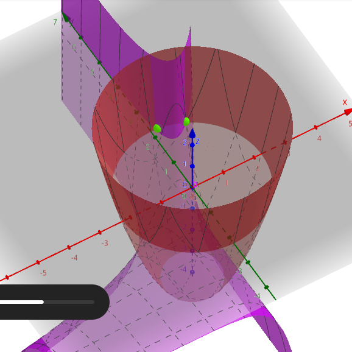

**Gráfica roja, morada y puntos verdes representan a $x^2+y^2-5$, $xe^y-e^{2x}$ y raices conjuntas, respectivamente**

La iteración bajo una selección de $\begin{pmatrix}x_0\\y_0\end{pmatrix}$ se efectuará con el siguiente código:

```r
# Definir la función
f <- function(vect) {
  x <- vect[1]
  y <- vect[2]
  c(x^2+y^2-5,x*exp(y)-exp(2*x))  # Ejemplo de sistema de dos ecuaciones
}
# Definir el Jacobiano
df <- function(vect) {
  x <- vect[1]
  y <- vect[2]
  matrix(c(2*x,2*y,exp(y)-2*exp(2*x),x*exp(y)), nrow = 2, byrow = TRUE)
}

# Función para realizar el método de Newton-Raphson
newton <- function(f, df, x0, tol = 1e-6, maxiter = 100) {
  # Punto inicial
  x <- x0

  # Iteraciones
  for (i in 1:maxiter) {
    # Calcular la función y su derivada en el punto actual
    f_val <- f(x)
    J <- df(x)

    # Solución del sistema lineal para encontrar la actualización
    delta_x <- solve(J, -f_val)

    # Actualizar el punto
    x <- x + delta_x

    # Verificar convergencia
    if (abs(sum(delta_x)) < tol) {
      return(x)
    }
  }
  warning("No se encontró convergencia en el máximo de iteraciones")
  return(NA)
}

# Ejemplo de uso
x0 <- c(.1,1.2)  # Punto inicial c(.1,1.2), c(.1,1.1)
root <- newton(f, df, x0)

if (all(!is.na(root))) {
  cat("Raíz encontrada:", root, "\n")
}
```

```
## Raíz encontrada: 0.1428824 2.231498
```